# NPQLL - Analysis

Stefanie Meliss

2024-05-05

### Sample size and manipulation checks

Data collection for the project closed on October 31st 2023 at 23:59. Up to this time point, we received N = 214 responses to the prior knowledge test and N = 151 responses to the learning outcome assessment. There is complete data (i.e., pre- and post-test measures) from N = 151 participants (75 in the experimental group and 76 in the control group.) Upon careful inspection of the learning outcome assessment data, two participants (one from each group) were identified who provided non-responses in at least 14 out of 15 free-text items. Data from these two participants were excluded from the analyses.

To determine whether any participants in that were exposed to the AO (non-AO) were indeed part of the experimental (control) group, we compared the user ids of participants randomly *assigned* to each group against the user ids of participants *exposed* to the respective introductory material.

No participant has accessed the AO that was not part of the experimental group. No participant has accessed the non-AO that was not part of the control group.

Some participants (N = 4) in the experimental group have not accessed the AO. Some participants (N = 3) in the control group have not accessed the non-AO. The respective participants were removed from further data analysis.

All participant in the experimental group have accessed the learning material. Some participants (N = 1) in the control group have not accessed the learning material.

The respective participants were removed from further data analysis. Engagement data from Steplab was further used to determine whether participants followed protocol. In the pre-registration, we specified that participants will be excluded if one of the following criteria is met: (1) The timestamp of when the object containing the to-be-learned material (Course 3, Module 1) was assessed predates the timestamp of when the object containing the prior knowledge assessment (Course 2, Module 1) was marked as completed; or (2) the object containing the to-be-learned material was assessed before the object containing the introductory material.

Due to inconsistencies in the data with respect to when the object containing the prior knowledge assessment was marked as completed, timestamp data from when the assessment itself was completed.

Some participants (N = 1) in the experimental group were excluded due to the first criteria. No participants in the control group were excluded due to the first criteria. The respective participants were removed from further data analysis. Some participants (N = 1) in the experimental group were excluded due to the second criteria. No participants in the control group were excluded due to the second criteria. The respective participants were removed from further data analysis. Data checks further revealed that some participants completed the learning outcome assessment without having accessed the learning material beforehand. Some participants (N = 1) in the experimental group were affected by this. Some participants (N = 2) in the control group were affected by this. The respective participants were removed from further data analysis. Lastly, the remaining data was checked for outliers. Outliers were defined as observations that are more than 1.5 IQR below Q1 or more than 1.5 IQR above Q3. Some participants (N = 1) in the experimental group were affected by this. Some participants (N = 1) in the control group were affected by this. The respective participants were removed from further data analysis.

The sample analysed here consisted of N = 134 participants.

In total, N = 122 participants have voluntarily provided information on their age and gender. Analysing the data showed that the mean reported age was 37.08 years (SD = 8.48). The sample consisted to 85.2% of females.

### Descriptive characteristics

##### Prior knowledge assessment

To assess participants’ prior knowledge on the topic of the learning material (i.e., development of reading abilities), a 10-item four-alternative forced-choice test was developed. The scope of the prior knowledge assessment was for each item to target a different construct relevant to the development of reading abilities (e.g., “An orthography is…”). For each item, the correct answer (i.e., “The set of conventions associated with a written language.”) together with three plausible distractors (e.g., “The set of conventions associated with a phonics system.”) was presented.

Participants were instructed to select the answer option that they think is correct and were encouraged to guess but discouraged from looking up the correct responses. The order of presentation of the ten items and corresponding distractors was randomised, and the same random order was applied across all participants. All items were presented on a single screen. Responses could only be submitted once each of the ten items has been completed.

Descriptives for whole sample and within each group

|  | n | mean | sd | median | trimmed | mad | min | max | range | skew | kurtosis | se |
| --- | --- | --- | --- | --- | --- | --- | --- | --- | --- | --- | --- | --- |
| all | 134 | 6.014925 | 1.751412 | 6 | 5.990741 | 1.4826 | 2 | 10 | 8 | 0.1107552 | 0.0033226 | 0.1512990 |
| AO | 66 | 5.803030 | 1.720641 | 6 | 5.759259 | 1.4826 | 2 | 10 | 8 | 0.2296713 | 0.0197678 | 0.2117963 |
| non-AO | 68 | 6.220588 | 1.769101 | 6 | 6.214286 | 1.4826 | 2 | 10 | 8 | -0.0119418 | 0.0080726 | 0.2145350 |

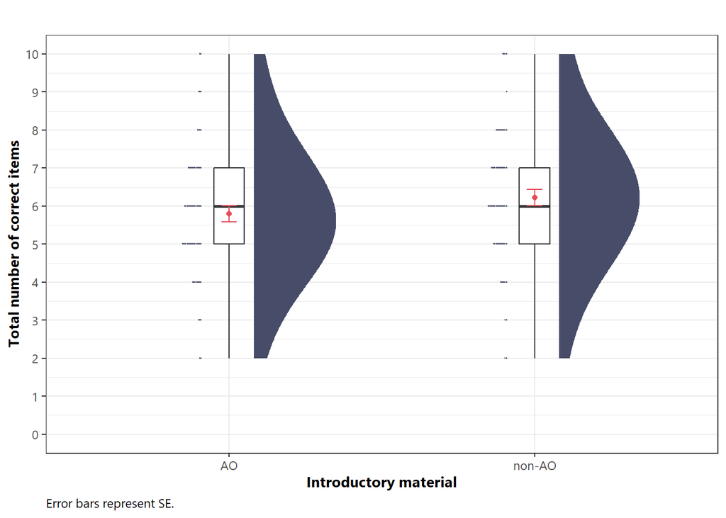

##### Learning outcome assessment

To determine whether exposure to an AO facilitates learning, an expert in the field (CS) developed a learning outcome assessment for the study. The learning outcome assessment targets information presented in the learning material. We created a set of 23 items capturing knowledge retention and transfer. The resulting learning outcome assessment consisted of 15 short answer items (e.g., “Complete this sentence: The smallest chunk of meaning within a word is called a __________.”) and 8 four-alternative forced-choice items. For each presented item (e.g., “Which of these are examples of comprehension strategies that might be used by pupils to support them to build meaning from a challenging text?”), participants were instructed to select all correct answers out of four alternatives they thought as correct (e.g., “Clarifying”, “Summarising”, “Highlighting”, “Blending”).

For each of the short answer items (e.g., “Please complete the following sentence: With extensive practice, the process of word recognition develops a sense of flow. This flow of words is called __________.”), the correct solution was determined before the assessment was administered (e.g., “(reading) fluency”). Additionally, all given answers were reviewed by a rater (CS) blind to the experimental condition and alternative acceptable solutions (e.g., “prosody”, “automaticity”) were identified. For each multiple-choice item with its four answer options, the pattern of selected/unselected options was compared against the correct pattern. This means that a point was awarded if an option was correctly selected and if an option was correctly not selected. However, due to an error, one multiple-choice item was set up to be a single-choice item, i.e., only one answer option could be selected. This item was scored as if it was a single item and a point was awarded if the correct answer was selected, but not if the incorrect answers were not selected. The maximum total score on the multiple-choice items was therefore 29.

Participants were provided with matching instructions for each item type. Participants were informed that incorrect answers in the multiple-choice items will be penalised. Further, they were instructed to not look up responses. The order of presentation of the items (and corresponding distractors, in case of multiple-choice items) was randomised, and the same random order was be applied across all participants. All items will be presented on a single screen. Responses could only be submitted if each of the items has been completed.

Descriptives for whole sample and within each group

|  | n | mean | sd | median | trimmed | mad | min | max | range | skew | kurtosis | se |
| --- | --- | --- | --- | --- | --- | --- | --- | --- | --- | --- | --- | --- |
| all | 134 | 36.18657 | 3.150768 | 36 | 36.21296 | 2.9652 | 28 | 43 | 15 | -0.1404951 | -0.2839146 | 0.2721849 |
| AO | 66 | 35.75758 | 3.186803 | 36 | 35.79630 | 2.9652 | 28 | 42 | 14 | -0.0772324 | -0.3352931 | 0.3922683 |
| non-AO | 68 | 36.60294 | 3.081673 | 37 | 36.62500 | 2.9652 | 29 | 43 | 14 | -0.1853312 | -0.2825139 | 0.3737077 |

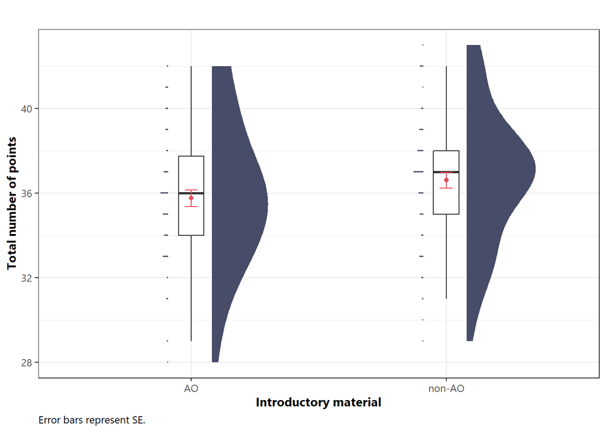

##### Change in knowledge

To determine whether there was an overall change in knowledge, the standardised score was computed for both assessments and plotted for each participant. No overall pattern emerges.

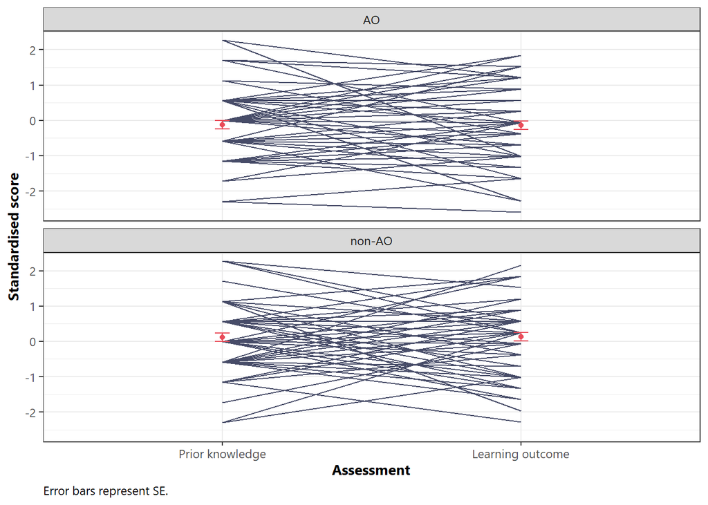

### Primary hypothesis test

Our primary hypothesis states that the exposure to an AO will improve the encoding of later presented, to-be-learned material. To test this hypothesis, an ANCOVA is used. We are interested in the main effect of experimental condition, i.e., whether an AO or historical overview, presented as introductory material, affects learning of the evidence summary (measured as the sum score of the learning outcome assessment), after controlling for prior knowledge at baseline (measured as the sum score of the prior knowledge assessment). The sum scores were standardised and the independent variable was dummy-coded (0 = “non-AO”, 1 = “AO”).

##### Assumption checks

Before conducting the ANCOVA, assumptions were checked. A Shapiro-Wilk test was used to determine whether residuals in the model were normally distributed. The results of the Shapiro-Wilk test indicated that the residuals did not significantly deviate from normality, W = 0.99, p = 0.462. This is further shown in the model plots below.

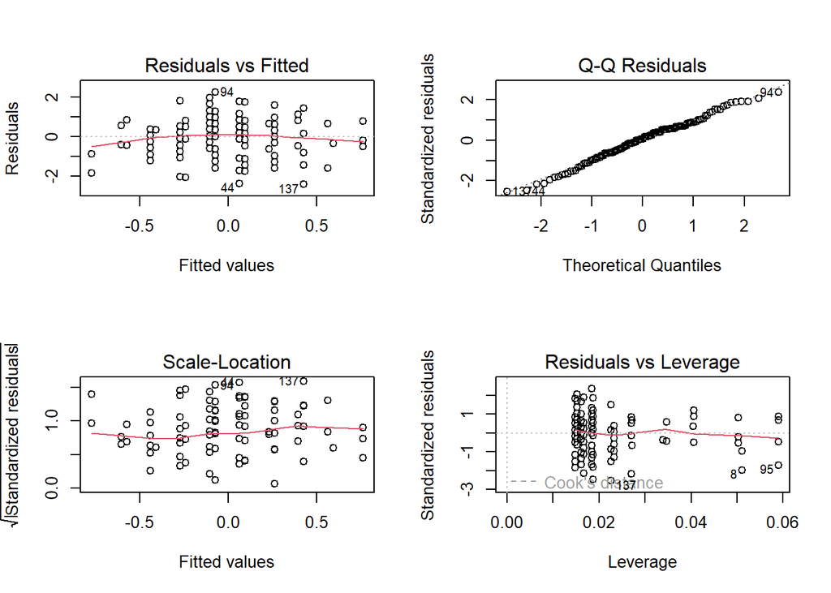

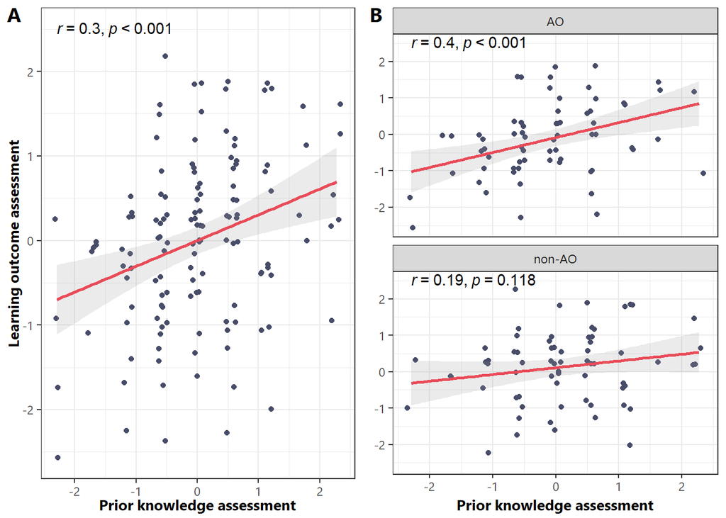

The results of the Bartlett test indicated that the assumption of homogeneity of the residual variances was met, Bartlett’s K-squared = 0.07, p = 0.791.

##### ANCOVA

An ANCOVA was run to determine the effect of introductory material on the learning outcome assessment score after controlling for prior knowledge assessment scores.

After adjustment for prior knowledge assessment score, there was no statistically significant difference in learning outcome assessment score between the groups, F(1, 131) = 1.43, p = 0.234. The covariate prior knowledge significantly predicted performance in the learning outcome assessment, F(1, 131) = 12.33, p = 0.001.

The results are summarised as type-III analysis-of-variance table below.

|  |  | SS | df | F value | p value | eta.sq.part |
| --- | --- | --- | --- | --- | --- | --- |
| 2 | AO effect | 1.30 | 1 | 1.43 | 0.234 | 0.01 |
| 4 | Prior knowledge | 11.24 | 1 | 12.33 | 0.001 | 0.09 |
| 3 | Residuals | 119.35 | 131 | NA | NA | NA |

Additionally, the results were transformed into the OLS regression out_m1put.

|  | score_posttest_c |  |  |  |  |
| --- | --- | --- | --- | --- | --- |
| Predictors | Estimates | CI | Statistic | p | df |
| Intercept | 0.10 | -0.13 – 0.33 | 0.84 | 0.402 | 131.00 |
| AO effect | -0.20 | -0.53 – 0.13 | -1.19 | 0.234 | 131.00 |
| Prior knowledge | 0.29 | 0.13 – 0.46 | 3.51 | **0.001** | 131.00 |
| Observations | 134 |  |  |  |  |
| R<sup>2</sup> / R<sup>2</sup> adjusted | 0.103 / 0.089 |  |  |  |  |

This indicates that our primary hypothesis - that exposure to an AO (compared to a control condition) during teacher professional development ahead of new, to-be-learned material will facilitate learning of the new material - could not be confirmed. The lack of effect of introductory material is further illustrated in the figure below, plotting the mean of the learning outcome assessment score in each group, adjusted for the prior knowledge effect.

##### Descriptives

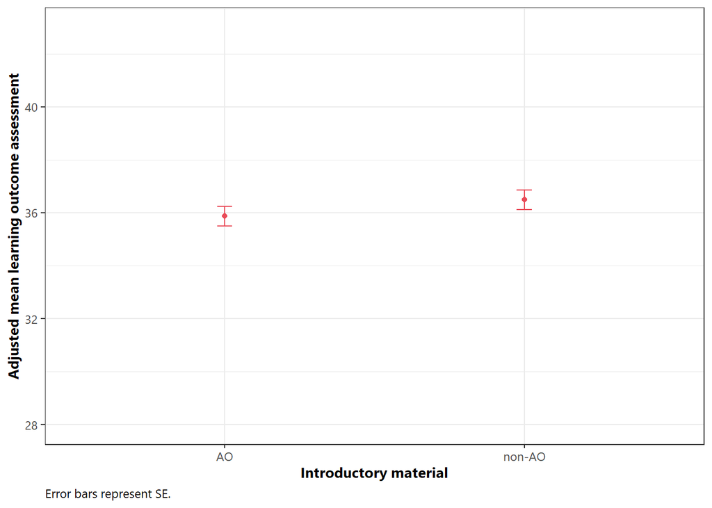

### Exploratory analyses

##### No Exclusion

To determine whether the decision to exclude observations influenced the results, the ANCOVA analysis were repeated using data from all N = 151 participants who completed the learning outcome assessment.

After adjustment for prior knowledge assessment score, there was no statistically significant difference in learning outcome assessment score between the groups, F(1, 148) = 0.03, p = 0.858. The covariate prior knowledge significantly predicted performance in the learning outcome assessment, F(1, 148) = 19.45, p = 0.

##### Pre-registered exclusion only

After adjustment for prior knowledge assessment score, there was no statistically significant difference in learning outcome assessment score between the groups, F(1, 134) = 1.3, p = 0.256. The covariate prior knowledge significantly predicted performance in the learning outcome assessment, F(1, 134) = 11.44, p = 0.001.

##### Sensitivity analyses

There may be other special cases where the participants have fallen behind in their online studies and Course 3 was released to them before they have completed the prior knowledge assessment in Course 2, Module 1. Likewise, participants may complete modules within a course in non-sequential order. In these cases, sensitivity analyses were conducted to determine whether the inclusion or exclusion of such participants impacted the results.

Course 3 was released to participants on 22nd May 2023. Some participants (N = 3) in the experimental group completed the prior knowledge assessment after this date. Some participants (N = 2) in the control group completed the prior knowledge assessment after this date. The respective participants were excluded before repeating the same ANCOVA analysis reported above. After adjustment for prior knowledge assessment score, there was no statistically significant difference in learning outcome assessment score between the groups, F(1, 126) = 0.85, p = 0.358. The covariate prior knowledge significantly predicted performance in the learning outcome assessment, F(1, 126) = 11.28, p = 0.001.

To determine whether participants completed the modules in course 3 in sequential order, timestamps of when the modules were marked as completed were used. If timestamps were missing for one or more modules, this was regarded as equivalent to completing modules in non-sequential order. Some participants (N = 7) in the experimental group were identified based on the second criteria. Some participants (N = 6) in the control group were identified based on the second criteria. The respective participants were excluded before repeating the same ANCOVA analysis reported above. After adjustment for prior knowledge assessment score, there was no statistically significant difference in learning outcome assessment score between the groups, F(1, 118) = 1.96, p = 0.165. The covariate prior knowledge significantly predicted performance in the learning outcome assessment, F(1, 118) = 10.34, p = 0.002.

##### Intervals

The intervals between (1) introductory material and evidence summary and (2) evidence summary and learning outcome assessment were be included as additional covariates to the ANCOVA model to determine whether the effect of exposure to an AO on learning remains after controlling for the time intervals. The intervals will be calculated using the timestamps associated with completion of the objects. The intervals will be standardised and checked for outliers to identify values that lie more than 1.5 interquartile ranges below the first or above the third quartile.

The interval between accessing the introductory material and evidence summary ranged from 4 to 4830053 seconds. The interval between accessing the evidence summary and completing the learning outcome assessment ranged from 0.021 to 145.821 days.

With respect to the first interval, N = 13 outliers were identified using the same IQR criteria described above. For the second interval, there were N = 0 outliers. For the sensiivity analyses, these outliers were removed. The average time interval between accessing the introductory material and evidence summary was 93.96 seconds (SD = 63.74). The average interval between accessing the learning material and completing the learning outcome assessment was 86.57 days (SD = 34.51). The time intervals were standardised and included as covariates. After adjustment for time intervals and prior knowledge assessment score, there was no statistically significant difference in learning outcome assessment score between the groups, F(1, 116) = 0.82, p = 0.366. The covariate prior knowledge significantly predicted performance in the learning outcome assessment, F(1, 116) = 10.72, p = 0.001.

|  | score_posttest_c |  |  |  |  |
| --- | --- | --- | --- | --- | --- |
| Predictors | Estimates | CI | Statistic | p | df |
| (Intercept) | 0.12 | -0.13 – 0.37 | 0.92 | 0.358 | 116.00 |
| group d | -0.17 | -0.54 – 0.20 | -0.91 | 0.366 | 116.00 |
| score pretest c | 0.29 | 0.12 – 0.47 | 3.27 | **0.001** | 116.00 |
| int 1 c | 0.10 | -0.08 – 0.28 | 1.14 | 0.256 | 116.00 |
| int 2 c | -0.00 | -0.19 – 0.18 | -0.05 | 0.963 | 116.00 |
| Observations | 121 |  |  |  |  |
| R<sup>2</sup> / R<sup>2</sup> adjusted | 0.111 / 0.080 |  |  |  |  |

##### Exposure to AO

The time in between participants first accessing the object containing the introductory materials and marking the object as completed can be seen as a proxy for how long they spent engaging with the introductory material. As such, we were interested to determine whether the inclusion of the engagement duration as a covariate impacts the results. This analysis was not pre-registered.

The interval between accessing the introductory material and evidence summary ranged from 2 to 8791465 seconds.

There were N = 18 outliers were identified using the same IQR criteria described above. These outliers were removed before conducting the analysis. The average time interval between accessing the introductory material and evidence summary was 94.24 seconds (SD = 68.65). The duration was standardised and included as covariate. After adjustment for time intervals and prior knowledge assessment score, there was no statistically significant difference in learning outcome assessment score between the groups, F(1, 112) = 0.97, p = 0.326. The covariate prior knowledge significantly predicted performance in the learning outcome assessment, F(1, 112) = 8.19, p = 0.005.

[output not shown]

##### Demographics

For the subset of participants that voluntarily provided demographic information, gender, and experience as classroom teacher were be included as additional covariates to test whether including additional demographic variables impacts the results. To also understand whether the manipulation may have differential effects depending on demographic variables, interaction terms with the effect-coded group variable were included.

Age was removed as predictor due to being highly correlated with experience, r = 0.76, p = .0.

However, as shown in the regression table below, demographic variables did not predict performance in the learning outcome assessment and also did not interact with the introductory material manipulation.

|  | score_posttest_c |  |  |  |  |
| --- | --- | --- | --- | --- | --- |
| Predictors | Estimates | CI | Statistic | p | df |
| (Intercept) | -0.01 | -0.20 – 0.17 | -0.13 | 0.900 | 116.00 |
| group e | -0.15 | -0.32 – 0.02 | -1.70 | 0.093 | 116.00 |
| score pretest c | 0.28 | 0.11 – 0.46 | 3.28 | **0.001** | 116.00 |
| gender [male] | 0.34 | -0.15 – 0.82 | 1.37 | 0.173 | 116.00 |
| experience c | 0.03 | -0.14 – 0.21 | 0.37 | 0.715 | 116.00 |
| group e × experience c | -0.09 | -0.27 – 0.08 | -1.07 | 0.287 | 116.00 |
| Observations | 122 |  |  |  |  |
| R<sup>2</sup> / R<sup>2</sup> adjusted | 0.138 / 0.101 |  |  |  |  |

##### Theta estimates from 2-paramter item-response-theory (IRT) models

To create an index of prior knowledge, it is possible to simply add up items to a sum score as done above. However, measurement theories and more specifically item response theory (IRT) can be applied to measure the latent knowledge score.

A uni-dimensional model was specified and the data for each item were supplied to the model using the *‘mirt package’* (Chalmers, 2012) to separately fit a two or three parameter logistic model, respectively. However, both models failed to converge. Exploratory analysis using theta estimates were hence not further pursued.

```
## EM cycles terminated after 500 iterations.
```

```
##
## Call:
## mirt(data = df[, paste0("question_", c(1:10), "_score")], model = unimodel,
##     itemtype = "2PL", verbose = FALSE)
##
## Full-information item factor analysis with 1 factor(s).
## FAILED TO CONVERGE within 0.0001 tolerance after 500 EM iterations.
## mirt version: 1.41
## M-step optimizer: BFGS
## EM acceleration: Ramsay
## Number of rectangular quadrature: 61
## Latent density type: Gaussian
##
## Log-likelihood = -777.9732
## Estimated parameters: 20
## AIC = 1595.946
## BIC = 1653.903; SABIC = 1590.638
## G2 (1003) = 343.87, p = 1
## RMSEA = 0, CFI = NaN, TLI = NaN
```

```
## EM cycles terminated after 500 iterations.
```

```
##
## Call:
## mirt(data = df[, paste0("question_", c(1:10), "_score")], model = unimodel,
##     itemtype = "3PL", verbose = FALSE)
##
## Full-information item factor analysis with 1 factor(s).
## FAILED TO CONVERGE within 0.0001 tolerance after 500 EM iterations.
## mirt version: 1.41
## M-step optimizer: BFGS
## EM acceleration: Ramsay
## Number of rectangular quadrature: 61
## Latent density type: Gaussian
##
## Log-likelihood = -770.4334
## Estimated parameters: 30
## AIC = 1600.867
## BIC = 1687.802; SABIC = 1592.905
## G2 (993) = 328.79, p = 1
## RMSEA = 0, CFI = NaN, TLI = NaN
```

### Learning experience survey

Upon completion of the learning assessment, participants were be asked to complete a short learning experience questionnaire (Wang et al., 2021).

> The type of learning material presented did not affect the learning experience ratings.

##### Satisfaction with introductory material

To assess satisfaction with introductory material, participants were asked to rate the item ‘Overall, I was satisfied with the introductory material presented ahead of the evidence summary in module 1 of course 3 (’Learning to read’).’ on a 7-point Likert scale from 1 = ‘Strongly disagree’ to 7 = ‘Strongly agree’.

Descriptives for whole sample and within each group

|  | n | mean | sd | median | trimmed | mad | min | max | range | skew | kurtosis | se |
| --- | --- | --- | --- | --- | --- | --- | --- | --- | --- | --- | --- | --- |
| all | 134 | 5.373134 | 1.248588 | 6 | 5.546296 | 0 | 1 | 7 | 6 | -1.667973 | 3.016897 | 0.1078616 |
| AO | 66 | 5.348485 | 1.270886 | 6 | 5.500000 | 0 | 1 | 7 | 6 | -1.325323 | 1.517558 | 0.1564353 |
| non-AO | 68 | 5.397059 | 1.235540 | 6 | 5.571429 | 0 | 1 | 7 | 6 | -1.988903 | 4.495005 | 0.1498312 |

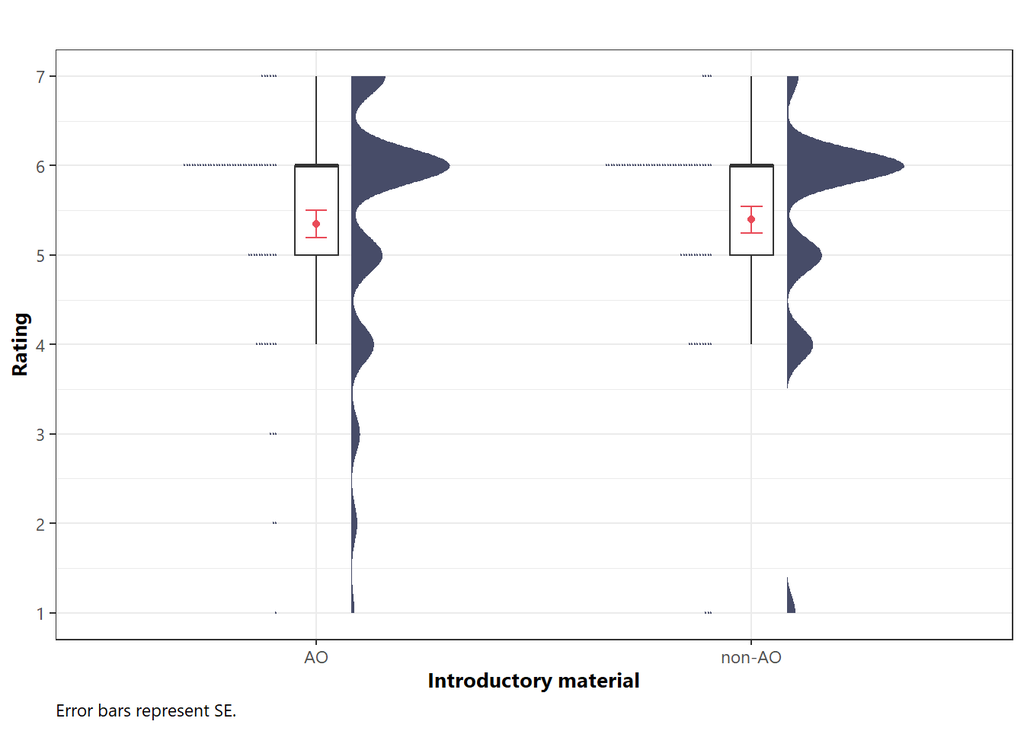

No significant difference in satisfaction with introductory material was found between the AO (M = 5.35, SD = 1.27) and non-AO (M = 5.4, SD = 1.24) group, t(131.55) = -0.22, p = 0.823.

##### Satisfaction with learning material

To assess satisfaction with learning material, participants were asked to rate the item ‘Overall, I was satisfied with the evidence summary presented in module 1 of course 3 (’Learning to read’).’ on a 7-point Likert scale from 1 = ‘Strongly disagree’ to 7 = ‘Strongly agree’.

Descriptives for whole sample and within each group

|  | n | mean | sd | median | trimmed | mad | min | max | range | skew | kurtosis | se |
| --- | --- | --- | --- | --- | --- | --- | --- | --- | --- | --- | --- | --- |
| all | 134 | 5.477612 | 1.148496 | 6 | 5.648148 | 0 | 1 | 7 | 6 | -1.704274 | 3.0557788 | 0.0992150 |
| AO | 66 | 5.469697 | 1.084431 | 6 | 5.611111 | 0 | 2 | 7 | 5 | -1.277783 | 0.9076161 | 0.1334842 |
| non-AO | 68 | 5.485294 | 1.215480 | 6 | 5.660714 | 0 | 1 | 7 | 6 | -1.956285 | 4.1354908 | 0.1473986 |

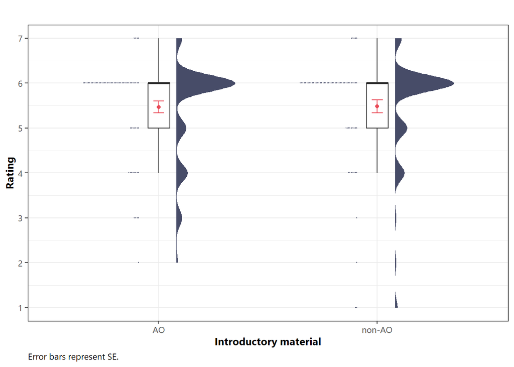

No significant difference in satisfaction with learning material was found between the AO (M = 5.47, SD = 1.08) and non-AO (M = 5.49, SD = 1.22) group, t(131.08) = -0.08, p = 0.938.

##### Effort

To assess effort, participants were asked to rate the item ‘How much mental effort did you invest to learn the content from the introductory material and evidence summary presented in module 1 of course 3 (’Learning to read’)?’ on a 7-point Likert scale from 1 = ‘Very, very low mental effort’ to 7 = ‘Very, very high mental effort’.

Descriptives for whole sample and within each group

|  | n | mean | sd | median | trimmed | mad | min | max | range | skew | kurtosis | se |
| --- | --- | --- | --- | --- | --- | --- | --- | --- | --- | --- | --- | --- |
| all | 134 | 4.850746 | 0.8628286 | 5 | 4.861111 | 0.0000 | 2 | 7 | 5 | -0.3394637 | 1.3525327 | 0.0745370 |
| AO | 66 | 4.909091 | 0.6956408 | 5 | 4.870370 | 0.0000 | 3 | 7 | 4 | 0.3883436 | 1.5015104 | 0.0856275 |
| non-AO | 68 | 4.794118 | 1.0008776 | 5 | 4.857143 | 1.4826 | 2 | 7 | 5 | -0.4686409 | 0.5536132 | 0.1213742 |

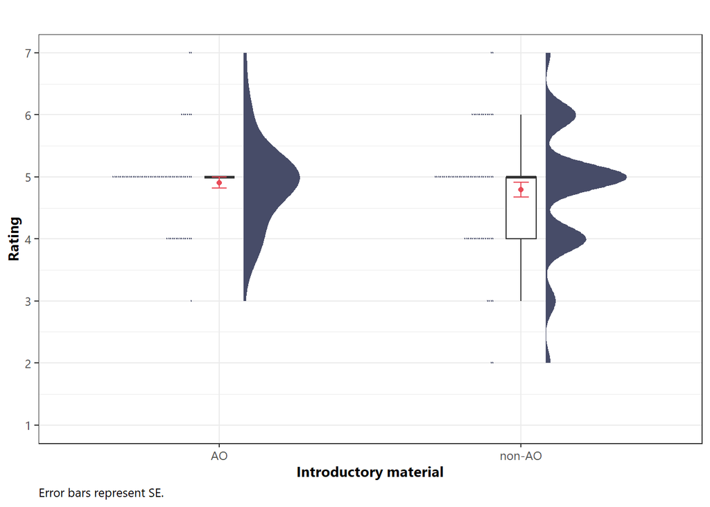

No significant difference in effort was found between the AO (M = 4.91, SD = 0.7) and non-AO (M = 4.79, SD = 1) group, t(119.72) = 0.77, p = 0.44.

##### Difficulty

To assess difficulty, participants were asked to rate the item ‘How difficult was it for you to learn the content from the introductory material and evidence summary presented in module 1 of course 3 (’Learning to read’)?’ on a 7-point Likert scale from 1 = ‘Very, very easy’ to 7 = ‘Very, very difficult’.

Descriptives for whole sample and within each group

|  | n | mean | sd | median | trimmed | mad | min | max | range | skew | kurtosis | se |
| --- | --- | --- | --- | --- | --- | --- | --- | --- | --- | --- | --- | --- |
| all | 134 | 4.246269 | 0.7090878 | 4 | 4.277778 | 0 | 2 | 7 | 5 | 0.2426421 | 1.3319478 | 0.0612559 |
| AO | 66 | 4.272727 | 0.6689936 | 4 | 4.277778 | 0 | 3 | 7 | 4 | 0.8531688 | 2.6172386 | 0.0823474 |
| non-AO | 68 | 4.220588 | 0.7500366 | 4 | 4.250000 | 0 | 2 | 6 | 4 | -0.1628547 | 0.2508506 | 0.0909553 |

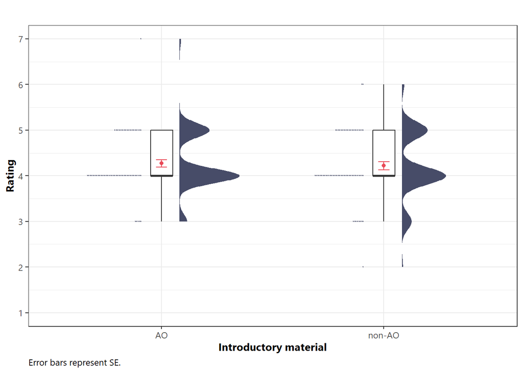

No significant difference in difficulty was found between the AO (M = 4.27, SD = 0.67) and non-AO (M = 4.22, SD = 0.75) group, t(131.08) = 0.42, p = 0.672.